# eda_report

## Exploratory Data Analysis

This report presents an exploratory analysis of a dataset aimed at understanding its structure, distributions, and relationships among features. The primary goal is to assess data quality, identify potential issues (such as missing values, skewness, or outliers), and gain preliminary insights to inform future modeling steps.

**Dataset Overview:**

- Number of observations: 15,000
- Number of numerical features: 6
- Number of categorical features: 1
- Target variable: `Calories`

This notebook covers summary statistics, missing data analysis, distribution visualizations, outlier detection, feature-target relationships, and correlation patterns.

```python
# Import necessary libraries
import numpy as np
import pandas as pd
import seaborn as sns
import matplotlib.pyplot as plt
import missingno as msno
import matplotlib.colors as mcolors
import io
from IPython.display import display, HTML, Markdown
from scipy.stats import pearsonr

# load data
df = pd.read_csv('/Users/morgannix/Data_Science/JupyterLab/Portfolio/calories_xs.csv')
```

Check for duplicate rows

```python
# User_ID is non-informative so we will set as index.
# first confirm there are no duplicates
# Check for duplicates in USER_ID
duplicate_ids = df['User_ID'].duplicated().sum()
print(f"Number of duplicate User_IDs: {duplicate_ids}")
```

```
Number of duplicate User_IDs: 0
```

```python
# set User_ID as index
df = df.set_index('User_ID')
```

### Summary Statistics

```python
# Show df.describe()
display(df.describe().style.format(precision=1))
```

|  | Age | Height | Weight | Duration | Heart_Rate | Body_Temp | Calories |
| --- | --- | --- | --- | --- | --- | --- | --- |
| count | 14369.0 | 14878.0 | 14865.0 | 14441.0 | 14501.0 | 14903.0 | 15000.0 |
| mean | 42.7 | 174.5 | 75.0 | 15.5 | 95.5 | 40.0 | 89.5 |
| std | 17.0 | 14.3 | 15.0 | 8.3 | 9.6 | 0.8 | 62.5 |
| min | 20.0 | 123.0 | 36.0 | 1.0 | 67.0 | 37.1 | 1.0 |
| 25% | 28.0 | 164.0 | 63.0 | 8.0 | 88.0 | 39.6 | 35.0 |
| 50% | 39.0 | 175.0 | 74.0 | 16.0 | 96.0 | 40.2 | 79.0 |
| 75% | 56.0 | 185.0 | 87.0 | 23.0 | 103.0 | 40.6 | 138.0 |
| max | 79.0 | 222.0 | 132.0 | 30.0 | 128.0 | 41.5 | 314.0 |

### Missing Data

This section presents the percentages of non-null values and a visual overview of the missingness pattern across the dataset/

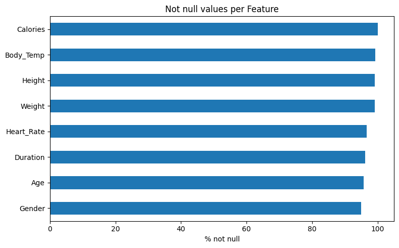

```python
# Count not nulls and calculate percentages
not_null_counts = 100 * df.notnull().sum()/df.shape[0]

# Bar plot of features in order of missingness
blue_hex = "#1f77b4"
blue_rgb = mcolors.to_rgb(blue_hex)
not_null_counts.sort_values().plot(kind='barh', figsize=(8, 5), color=blue_rgb)
plt.title('Not null values per Feature')
plt.xlabel('% not null')
plt.tight_layout()
plt.show()
```

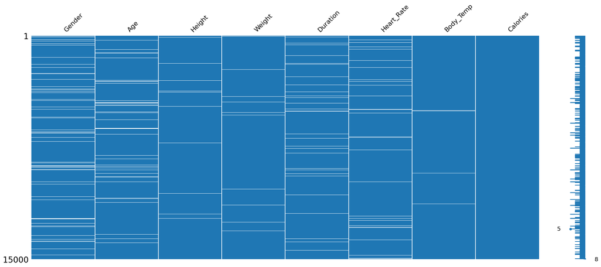

```python
# Visualize the pattern of missing data across the dataset

msno.matrix(df, color=blue_rgb)
plt.show()
```

All features (except the target) have between 0% and 5% missing values. For these plots blue represents present values and white, missing values. Each horizontal white line represents a missing value. Missingness appears to be independent across features, suggesting a pattern consistent with Missing Completely at Random (MCAR). The vertical "comb" on the right side of the plot shows the number of present values per row, ranging from a minimum of 5 (i.e., 3 missing values) to a maximum of 8 (0 missing values).

### Distribution Analysis

#### Histograms and Count plots

This section presents histograms and count plots for features and target, grouped by Gender.

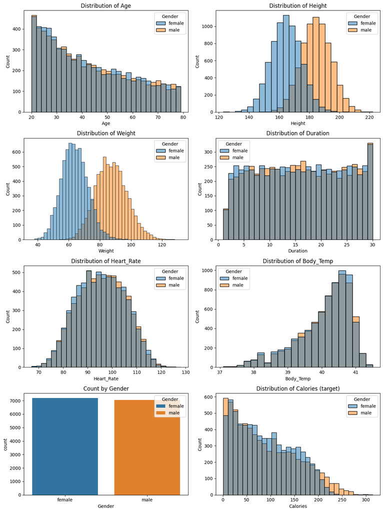

```python
# create a grid
fig, axes = plt.subplots(4, 2, figsize=(12, 16))
# Flatten axes array to simplify iteration over subplots
axes = axes.flatten()

# plot numerical features and set bin widths manually based on range of observations
cols_and_widths = [('Age', 2), ('Height', 4), ('Weight', 2), ('Duration', 1), ('Heart_Rate', 2),
    ('Body_Temp', 0.2)]

for i, col_and_width in enumerate(cols_and_widths):
    col, bin_width = col_and_width
    sns.histplot(
        data=df,
        x=col,
        hue='Gender', # superimpose separate plots for Gender
        alpha=0.5, # transparency for superimposed plots
        binwidth=bin_width,
        ax=axes[i]
    )
    axes[i].set_title(f'Distribution of {col}')

# add categorical feature 'Gender'
sns.countplot(
    data=df,
    x='Gender',
    hue='Gender',
    ax=axes[6]
)
axes[6].set_title('Count by Gender')

# plot 'Calories' last
sns.histplot(
        data=df,
        x='Calories',
        hue='Gender',
        alpha=0.5,
        binwidth=10,
        ax=axes[7]
    )
axes[7].set_title(f'Distribution of Calories (target)')
plt.tight_layout()
plt.show()
```

The distribution of Age appears significantly right skewed and Body_Temp appears left skewed. All other numerical features appear to be symmetrical in their distribution. The target (Calories) appears right skewed.

#### Gender counts

```python
# calculate counts and percentages, keeping nulls
gender_counts = df['Gender'].value_counts(dropna=False)
gender_percent = df['Gender'].value_counts(normalize=True, dropna=False) * 100
gender_counts_df = pd.DataFrame({
    'Count': gender_counts,
    'Percent': gender_percent.round(1)
})
display(gender_counts_df)
```

| Gender | Count | Percent |
| --- | --- | --- |
| female | 7190 | 47.9 |
| male | 7063 | 47.1 |
| NaN | 747 | 5.0 |

The data is fairly evenly split between female and male

#### Box plots

This section presents Box and Whisker plots for numerical features and target, grouped by Gender. The box represents the middle 50% of the observations, from the 1st to 3rd quartiles. The line inside the box is the median. The points outside the whiskers represent potential outliers according to Tukey’s method

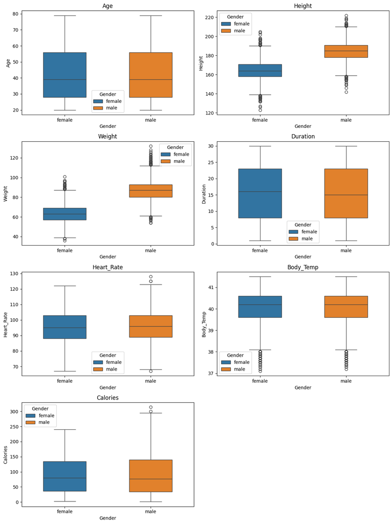

```python
# create grid
fig, axes = plt.subplots(4, 2, figsize=(12, 16))  # 4 rows, 2 columns (7 plots + 1 empty)
axes = axes.flatten()

cols = ['Age', 'Height', 'Weight', 'Duration', 'Heart_Rate', 'Body_Temp', 'Calories']

for i, col in enumerate(cols):
    sns.boxplot(
        data=df,
        x='Gender',
        hue='Gender', # parallel plots for each Gender
        y=col,
        ax=axes[i],
        width=0.5,
    )
    axes[i].set_title(col)

# Remove empty subplot
fig.delaxes(axes[-1])

plt.tight_layout()
plt.show()
```

There are potential outliers in observations of Height, Weight, Heart_Rate, Body_Temp and Calories.

#### Potential outlier counts

For normally distributed data we would expect 0.35% of the observations to be below the lower bound and 0.35% to be above the upper bound of the box plot. Although some of the features appear to be skewed (ie non-normal), I will use this as a baseline to investigate outlier counts. The next section presents counts of potential outliers.

```python
def get_outlier_count(feature):
    """
    Calculate the percentage of outliers below and above the IQR bounds for a given feature.

    Outliers are defined using the IQR method:
        Lower bound = Q1 - 1.5 * IQR
        Upper bound = Q3 + 1.5 * IQR

    Parameters:
        feature (str): The name of the column in df to analyze.

    Returns:
        tuple: (percentage of low outliers, percentage of high outliers)
    """

    # Calculate Q1, Q3, and IQR
    Q1 = df[feature].quantile(0.25)
    Q3 = df[feature].quantile(0.75)
    IQR = Q3 - Q1

    # Define bounds
    lower_bound = Q1 - (1.5 * IQR)
    upper_bound = Q3 + (1.5 * IQR)

    # Filter outliers
    low_outliers = df[df[feature] < lower_bound]
    high_outliers = df[df[feature] > upper_bound]

    return low_outliers.shape[0]/ df.shape[0] * 100, high_outliers.shape[0]/ df.shape[0] * 100
```

```python
# calculate potential outlier counts
data = []
for col in cols:
    low, high = get_outlier_count(col)
    data.append({
        'Column': col,
        '% Below Lower Bound': low,
        '% Above Upper Bound': high,
    })

outlier_df = pd.DataFrame(data)
def highlight_outliers(val):
    # normally distributed data would expect 0.35% below/above the lower/upper bound
    color = 'background-color: lightcoral' if val > 0.35 else ''
    return color

styled_df = outlier_df.style.map(
    highlight_outliers, subset=['% Below Lower Bound', '% Above Upper Bound']
    ).format("{:.3f}", subset=['% Below Lower Bound', '% Above Upper Bound'])

display(styled_df.hide(axis="index"))
```

| Column | % Below Lower Bound | % Above Upper Bound |
| --- | --- | --- |
| Age | 0.000 | 0.000 |
| Height | 0.053 | 0.040 |
| Weight | 0.000 | 0.040 |
| Duration | 0.000 | 0.000 |
| Heart_Rate | 0.000 | 0.007 |
| Body_Temp | 2.453 | 0.000 |
| Calories | 0.000 | 0.027 |

### Relationships and Correlations

#### Scatterplots of features vs target

This section presents scatterplots of numerical features against Calories, color-coded by Gender. These plots provide a visual indication of the functional relationships between each feature and the target variable.

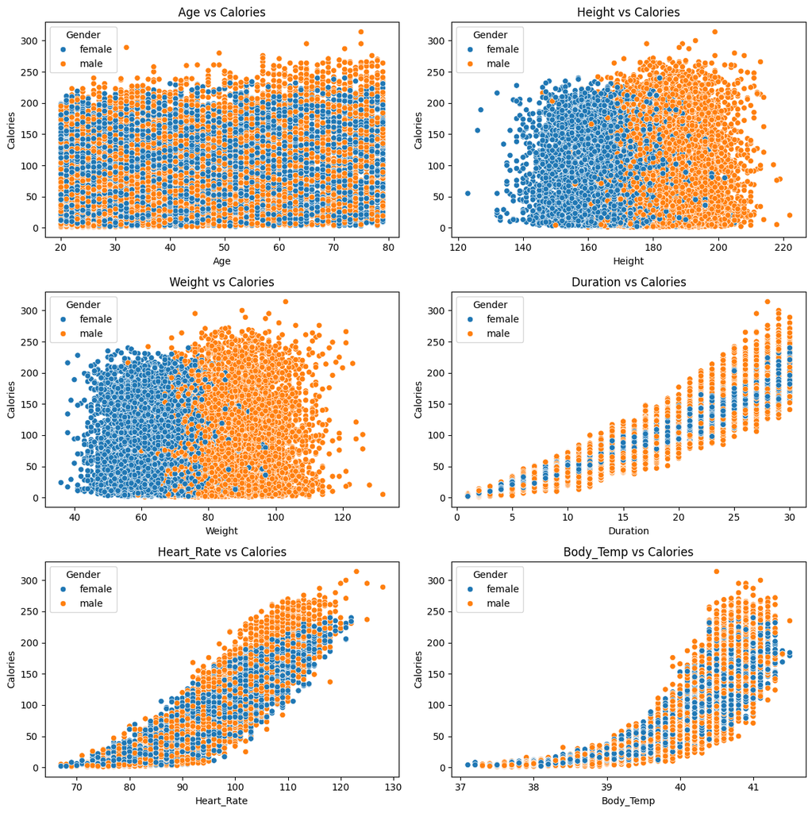

```python
features = ['Age', 'Height', 'Weight', 'Duration', 'Heart_Rate', 'Body_Temp']
target = 'Calories'

# Set up subplot grid: 2 columns, automatic rows
n_cols = 2
n_rows = (len(features) + 1) // n_cols

fig, axes = plt.subplots(n_rows, n_cols, figsize=(12, 4 * n_rows))
axes = axes.flatten()  # flatten to 1D for easy indexing

for i, feature in enumerate(features):
    sns.scatterplot(x=df[feature], y=df[target], hue=df['Gender'], ax=axes[i])
    axes[i].set_title(f"{feature} vs {target}")
    axes[i].set_xlabel(feature)
    axes[i].set_ylabel(target)

# Remove any empty subplots
for j in range(i + 1, len(axes)):
    fig.delaxes(axes[j])

plt.tight_layout()
plt.show()
```

The scatterplot of Age against Calories shows no clear pattern, suggesting little to no functional relationship between the two variables.  
The scatterplot of Height against Calories shows no clear pattern, suggesting little to no functional relationship between the two variables. However, there is clear evidence of difference in Height means for each Gender, as observed previously in the Distribution analysis.  
The scatterplot of Weight against Calories shows no clear pattern, suggesting little to no functional relationship between the two variables. However, there is clear evidence of difference in Weight means for each Gender, as observed previously in the Distribution analysis.  
The scatterplot of Duration against Calories shows a positive correlation, suggesting a linear relationship with potential non-linear effects. The plot reveals a cone-shaped spread, where the variance of Calories appears to increase with Duration. This is a visual indicator of heteroscedasticity. There is also evidence of higher variance in observations for Males compared with Females, as observed in the Distribution analysis.  
The scatterplot of Heart_Rate against Calories shows a positive correlation, suggesting a linear relationship with potential non-linear effects. There is also evidence or heteroscedasticity in Calories with respect to Heart_Rate.  
The scatterplot of Body_Temp against Calories shows a positive correlation and suggests a nonlinear relationship. There is also evidence or heteroscedasticity in Calories with respect to Body_Temp.

#### Correlations

This section presents a correlation matrix showing the pairwise Pearson correlation coefficients for features and target. To include the categorical feature Gender it has been binary-encoded.

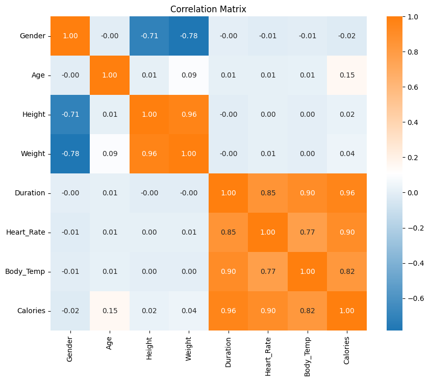

```python
# make a copy to avoid altering the original
X = df.copy()
# binary encode
X['Gender'] = X['Gender'].map({'male': 0, 'female': 1})

plt.figure(figsize=(10, 8))
# custom colour to match histograms and Box plots
custom_cmap = mcolors.LinearSegmentedColormap.from_list("custom",
    [blue_hex, "white", "#ff7f0e"])

sns.heatmap(X.corr(), annot=True,
            cmap=custom_cmap,
            fmt=".2f")
plt.title("Correlation Matrix")
plt.show()
```

Height, Weight, and Gender are significantly correlated with each other, which is consistent with earlier observations that the means of Height and Weight differ between genders.  
Duration, Heart_Rate and Body_Temp are significantly correlated with the target which is consistent with the scatterplots of these features against Calories. They are also significantly correlated with one another.  
Given these insights, it would be useful to further investigate the functional relationships between Height and Weight, and pairwise between Duration, Heart_Rate and Body_Temp. The next section presents these.

#### Scatterplots of features

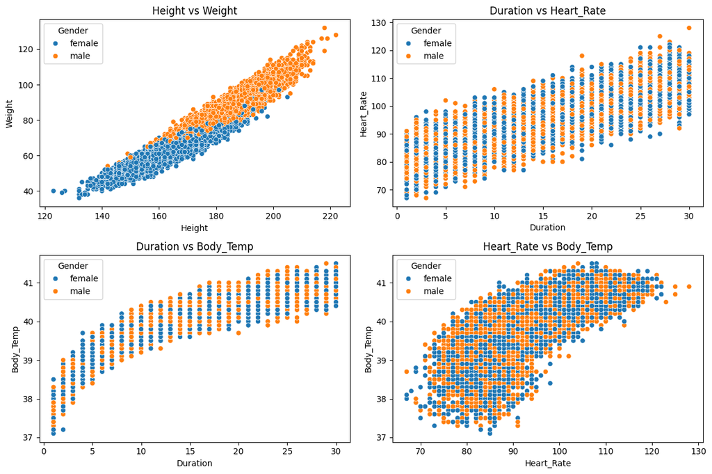

```python
fig, axes = plt.subplots(2, 2, figsize=(12, 8))
axes = axes.flatten()  # flatten to 1D for easy indexing

sns.scatterplot(x=df['Height'], y=df['Weight'], hue=df['Gender'], ax=axes[0])
axes[0].set_title(f"Height vs Weight")
axes[0].set_xlabel("Height")
axes[0].set_ylabel("Weight")

sns.scatterplot(x=df['Duration'], y=df['Heart_Rate'], hue=df['Gender'], ax=axes[1])
axes[1].set_title(f"Duration vs Heart_Rate")
axes[1].set_xlabel("Duration")
axes[1].set_ylabel("Heart_Rate")

sns.scatterplot(x=df['Duration'], y=df['Body_Temp'], hue=df['Gender'], ax=axes[2])
axes[2].set_title(f"Duration vs Body_Temp")
axes[2].set_xlabel("Duration")
axes[2].set_ylabel("Body_Temp")

sns.scatterplot(x=df['Heart_Rate'], y=df['Body_Temp'], hue=df['Gender'], ax=axes[3])
axes[3].set_title(f"Heart_Rate vs Body_Temp")
axes[3].set_xlabel("Heart_Rate")
axes[3].set_ylabel("Body_Temp")

plt.tight_layout()
plt.show()
```

The scatterplot of Weight against Height shows a strong positive correlation suggesting a linear relationship. There is also a clear gender-based pattern: males are concentrated around higher values for both Weight and Height, while females are more concentrated around lower values. This is consistent with previous observations.  
The scatterplot of Duration against Heart_Rate shows a positive correlation suggesting a linear relationship.  
The scatterplot of Duration against Body_Temp shows a positive, but likely non-linear, relationship.  
The scatterplot of Heart_Rate against Body_Temp shows a generally positive relationship, but with high variance and a non-linear relationship.

### Next steps

#### Missing Data

The goal of this analysis is to prepare the dataset for statistical modeling, including interpretable approaches such as linear regression. Since many models cannot handle missing values, we need to address the missing data appropriately as part of the preprocessing stage.  
We could explore using the relationships between correlated features to perform imputations based on linear regression (numerical features) and logistic regression (categorical feature).

#### Feature Engineering

We could explore Principal Component Analysis (PCA)<sup>[ⓘ](https://en.wikipedia.org/wiki/Principal_component_analysis)</sup> as a method to combine correlated features. In particular, Height and Weight—which are highly correlated—could be combined into a single feature such as Body Mass Index (BMI), which is both interpretable and familiar to many readers.

Heteroscedasticity of Calories with respect to three features suggests that a transformation of the target may be appropriate. Given the right-skewed distribution of Calories, a log or Box-Cox transformation could be considered.  
Categorical feature Gender can be binary-encoded.